# **Customer Churn em Operadoras de Telecom**

Giuliana Farabolini

4/11/2021

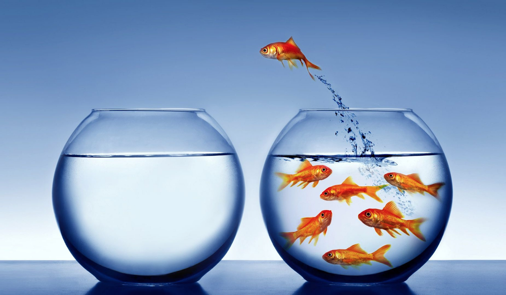

# **1.Objetivo**

O projeto possui o foco de criar um modelo de aprendizado de máquina para prever se um cliente pode ou não cancelar seu plano e a probabilidade disso ocorrer. Para desenvolver o estudo utilizaremos a linguagem R.

# **2. Introdução**

## 2.1 O que é Customer Churn?

Churn é uma métrica que indica o número de clientes que reincidem seus contratos em determinado período. Para calcular o churn, o que você precisa fazer é somar o número de clientes que cancelou seu produto/serviço no período analisado.

Para que uma empresa consiga fazer a expansão da sua base de clientes, é preciso que o número de novos clientes exceda o seu churn rate – a taxa de clientes cancelados.

- Churn = total de clientes cancelados

*Fonte: (https://resultadosdigitais.com.br/blog/o-que-e-churn/); acessado em 11 de abril de 2021.*

## 2.2 O que é análise preditiva?

Análise preditiva é uma técnica analítica avançada que usa dados, algoritmos e machine learning para antecipar tendências e fazer projeções nos negócios. Graças ao avanço computacional, já é possível analisar grandes volumes de dados (Big Data) para encontrar padrões e avaliar as futuras possibilidades a partir do histórico da empresa.

*Autor: Patel, Neil; (https://neilpatel.com/br/blog/analise-preditiva/); acessado em 11 de abril de 2021.*

## 2.3 Por que usar análise preditiva para diminuir churn rate?

- Gerenciar riscos;
- Suportar a tomada de decisão;
- Diminuir custos;
- Aumentar o alcance dos negócios;
- Identificar produtos mais desejados;
- Prever Churn;
- Detectar fraudes.

*Autor: Alcantara, Joyce; (https://e-millennium.com.br/o-que-e-analise-preditiva-e-como-ela-agrega-valor-para-os-negocios/); acessado em 11 de abril de 2021.*

# **3. Dataset**

## 3.1 Obtenção e importação dos dados

O banco de dados foi extraído do site Kaggle e vamos importá-lo para software.

```r
churn <- read.csv('/Users/giulianafarabolini/Downloads/WA_Fn-UseC_-Telco-Customer-Churn.csv')
```

## 3.2 Dicionário:

- **customerID:** 7043 ID’s únicos, cada um representando um cliente;
- **gender:** gênero do cliente;
- **SeniorCitizen:** se o cliente é idoso ou não;
- **Partner:** se cliente tem um cônjuge ou não;
- **Dependents:** se o cliente possui dependentes ou não;
- **tenure:** número de meses que o cliente está/ficou na companhia;
- **PhoneService:** se o cliente possui serviço de telefone ou não;
- **MultipleLines:** se o cliente possui múltiplas linhas de telefone;
- **InternetService:** tipo de serviço de internet;
- **OnlineSecurity:** se o cliente possui algum tipo de proteção online;
- **OnlineBackup:** se o cliente tem backup online;
- **DeviceProtection:** se o cliente possui algum tipo de proteção para celular;
- **TechSupport:** se o cliente tem suporte técnico;
- **StreamingTV:** se o cliente tem serviço de streaming de TV (TV por assinatura);
- **StreamingMovies:** se o cliente tem algum tipo de serviço de streaming para filmes (Netflix, Telecine, Amazon Prime, etc…);
- **Contract:** duração do contrato;
- **PaperlessBilling:** se o cliente recebe a fatura virtualmente (sem a impressão de papel);
- **PaymentMethod:** método de pagamento utilizado;
- **MonthlyCharges:** valor da fatura mensal do cliente;
- **TotalCharges:** valor total já pago pelo cliente;
- **Churn:** variável indicando se o cliente rescindiu ou não seu contrato com a companhia no último mês.

Vamos analisar o banco de dados e suas características:

```r
str(churn)
```

```
## 'data.frame':    7043 obs. of  21 variables:
##  $ customerID      : chr  "7590-VHVEG" "5575-GNVDE" "3668-QPYBK" "7795-CFOCW" ...
##  $ gender          : chr  "Female" "Male" "Male" "Male" ...
##  $ SeniorCitizen   : int  0 0 0 0 0 0 0 0 0 0 ...
##  $ Partner         : chr  "Yes" "No" "No" "No" ...
##  $ Dependents      : chr  "No" "No" "No" "No" ...
##  $ tenure          : int  1 34 2 45 2 8 22 10 28 62 ...
##  $ PhoneService    : chr  "No" "Yes" "Yes" "No" ...
##  $ MultipleLines   : chr  "No phone service" "No" "No" "No phone service" ...
##  $ InternetService : chr  "DSL" "DSL" "DSL" "DSL" ...
##  $ OnlineSecurity  : chr  "No" "Yes" "Yes" "Yes" ...
##  $ OnlineBackup    : chr  "Yes" "No" "Yes" "No" ...
##  $ DeviceProtection: chr  "No" "Yes" "No" "Yes" ...
##  $ TechSupport     : chr  "No" "No" "No" "Yes" ...
##  $ StreamingTV     : chr  "No" "No" "No" "No" ...
##  $ StreamingMovies : chr  "No" "No" "No" "No" ...
##  $ Contract        : chr  "Month-to-month" "One year" "Month-to-month" "One year" ...
##  $ PaperlessBilling: chr  "Yes" "No" "Yes" "No" ...
##  $ PaymentMethod   : chr  "Electronic check" "Mailed check" "Mailed check" "Bank transfer (automatic)" ...
##  $ MonthlyCharges  : num  29.9 57 53.9 42.3 70.7 ...
##  $ TotalCharges    : num  29.9 1889.5 108.2 1840.8 151.7 ...
##  $ Churn           : chr  "No" "No" "Yes" "No" ...
```

A tabela é composta por 7.043 observações(linhas) e 21 variáveis (colunas).

# 3.3 Limpeza e preparação dos dados

A maioria das variáveis entrou como classificação *caracter*, porém a maior parte da base é *factor*, por isso vamos alterar suas classes:

```r
library(dplyr)
churn <- churn %>%
  mutate_at(vars(2:5,7:18,21), as.factor)
```

As colunas 10 a 15 tem observações que são diferentes, mas possuem o mesmo significado. Para facilitar a análise iremos substitui-las e unificar as observações.

```r
churn[churn == 'No internet service'] <- 'No'
```

O mesmo acontece com a coluna *MultipleLines*, vamos repetir a ação anterior, porém com a observação *“No phone service”*.

```r
levels(churn$MultipleLines)
```

```
## [1] "No"               "No phone service" "Yes"
```

```r
levels(churn$MultipleLines) <- c('No', 'No', 'Yes')
```

Já a coluna *SeniorCitizen* traz a informação ‘1’ para quem é idoso e ‘0’ para o contrário, como feito anteriormente vamos substituir esses valores para ‘Yes’ e ‘No’, respectivamente para uniformizar nossa base.

```r
levels(churn$SeniorCitizen)
```

```
## [1] "0" "1"
```

```r
levels(churn$SeniorCitizen) <- c('No', 'Yes')
```

Verificando se a base possui valores nulos

```r
sum(is.na(churn))
```

```
## [1] 11
```

Temos valores nulos, agora vamos identificar em qual coluna estão:

```r
sapply(churn, function(x) sum(is.na(x)))
```

```
##       customerID           gender    SeniorCitizen          Partner
##                0                0                0                0
##       Dependents           tenure     PhoneService    MultipleLines
##                0                0                0                0
##  InternetService   OnlineSecurity     OnlineBackup DeviceProtection
##                0                0                0                0
##      TechSupport      StreamingTV  StreamingMovies         Contract
##                0                0                0                0
## PaperlessBilling    PaymentMethod   MonthlyCharges     TotalCharges
##                0                0                0               11
##            Churn
##                0
```

Observamos que todos os valores nulos estão na coluna *TotalCharges*, mas como o dataset nos traz os valores pagos no mês e tempo do contrato, podemos criar os valores nulos se houver necessidade.

```r
churn[is.na(churn$TotalCharges),1:6]
```

```
##      customerID gender SeniorCitizen Partner Dependents tenure
## 489  4472-LVYGI Female            No     Yes        Yes      0
## 754  3115-CZMZD   Male            No      No        Yes      0
## 937  5709-LVOEQ Female            No     Yes        Yes      0
## 1083 4367-NUYAO   Male            No     Yes        Yes      0
## 1341 1371-DWPAZ Female            No     Yes        Yes      0
## 3332 7644-OMVMY   Male            No     Yes        Yes      0
## 3827 3213-VVOLG   Male            No     Yes        Yes      0
## 4381 2520-SGTTA Female            No     Yes        Yes      0
## 5219 2923-ARZLG   Male            No     Yes        Yes      0
## 6671 4075-WKNIU Female            No     Yes        Yes      0
## 6755 2775-SEFEE   Male            No      No        Yes      0
```

Vemos que os clientes que estão com valores nulos é porque possuem o tempo de contrato zero, ou seja, não realizaram o primeiro pagamento. Será que temos outros clientes com o tempo de contrato zerado?

```r
library(dplyr)
churn %>%
    filter(tenure == 0) %>%
    summarize("Zero Tenure" = n())
```

```
##   Zero Tenure
## 1          11
```

Esses são os únicos clientes, então vamos removê-los do dataset, já que não possuem um tempo considerável de contrato para influenciar as nossas análises, além do que essas observações representam apenas 0,15% do banco de dados total.

```r
nondchurn <- churn[complete.cases(churn), ]
dim(nondchurn)
```

```
## [1] 7032   21
```

Não precisaremos da variável *customerID* para gráficos ou modelagem, portanto, ela pode ser removida.

```r
nvdatasetchurn <- nondchurn %>%
                select(-customerID)
```

# **4. Análise Exploratória**

## 4.1 Taxa Churn

O conjunto de dados nos traz que 26,58% dos clientes reincidiram os contratos.

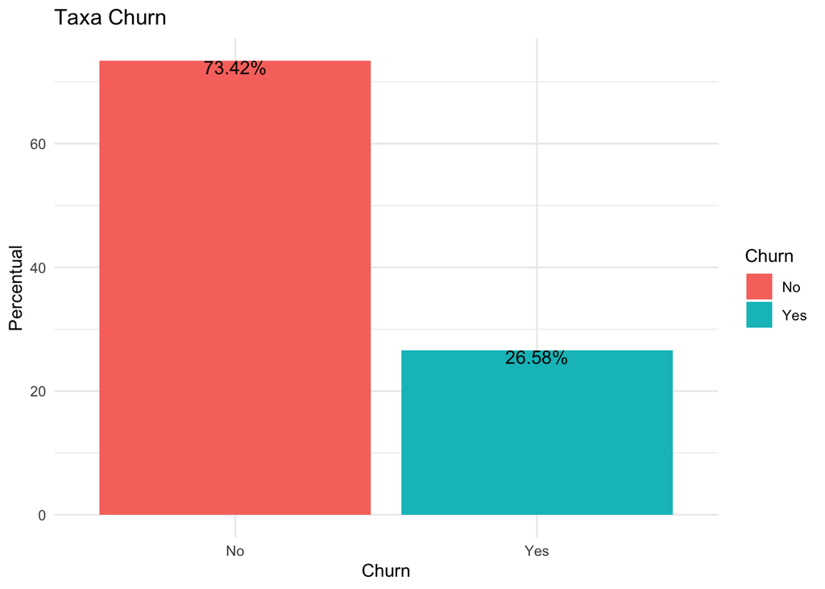

```r
library(ggplot2)

nvdatasetchurn %>%
  group_by(Churn) %>%
  summarise(Number = n()) %>%
  mutate(Percentual = prop.table(Number)*100) %>%
ggplot(aes(Churn, Percentual)) +
  geom_col(aes(fill = Churn)) +
  labs(title = "Taxa Churn") +
  theme(plot.title = element_text(hjust = 0.5)) +
  geom_text(aes(label = sprintf("%.2f%%", Percentual)), hjust = 0.5,vjust =1, size = 4) +
  theme_minimal()
```

## 4.2 Perfil do cliente churn

Antes de começarmos a fazer nossa modelagem, vamos analisar os perfis dos clientes.

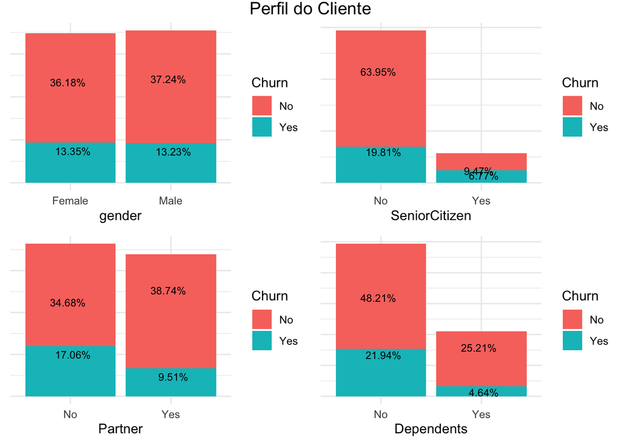

```r
library(cowplot)
library(stringr)

plot_grid(ggplot(nvdatasetchurn, aes(x = gender, fill = Churn)) +
            geom_bar() +
            geom_text(aes(y = ..count.. -200,
                          label = paste0(round(prop.table(..count..),4) * 100, '%')),
                      stat = 'count', position = position_dodge(.1), size = 3)+
            theme_minimal()+
             theme(axis.text.y = element_blank(),
              axis.ticks.y = element_blank(),
              axis.title.y = element_blank()),
          ggplot(nvdatasetchurn, aes(x = SeniorCitizen, fill = Churn)) +
            geom_bar() +
            geom_text(aes(y = ..count.. -200,
                          label = paste0(round(prop.table(..count..),4) * 100, '%')),
                      stat = 'count', position = position_dodge(.1), size = 3)+
            theme_minimal()+
             theme(axis.text.y = element_blank(),
              axis.ticks.y = element_blank(),
              axis.title.y = element_blank()),
          ggplot(nvdatasetchurn, aes(x = Partner, fill = Churn)) +
            geom_bar() +
            geom_text(aes(y = ..count.. -200,
                          label = paste0(round(prop.table(..count..),4) * 100, '%')),
                      stat = 'count', position = position_dodge(.1), size = 3)+
            theme_minimal()+
             theme(axis.text.y = element_blank(),
              axis.ticks.y = element_blank(),
              axis.title.y = element_blank()),
          ggplot(nvdatasetchurn, aes(x = Dependents, fill = Churn)) +
            geom_bar() +
            geom_text(aes(y = ..count.. -200,
                          label = paste0(round(prop.table(..count..),4) * 100, '%')),
                      stat = 'count', position = position_dodge(.1), size = 3)+
            theme_minimal()+
             theme(axis.text.y = element_blank(),
              axis.ticks.y = element_blank(),
              axis.title.y = element_blank()))+
        labs(title = "Perfil do Cliente") +
        theme(plot.title = element_text(hjust = 0.5))
```

A partir dos gráficos podemos ver que a mostra é dívida uniformemente por gênero e status de parceiro. Uma minoria da amostra é idosa e a grande maioria não possui dependentes. Conseguimos perceber que o perfil dos clientes não churn e dos clientes churn diferem apenas na variável *partner*, onde os clientes que reincidiram o contrato a maioria não possui companheiro e já os clientes não churn a maioria possui companheiros.

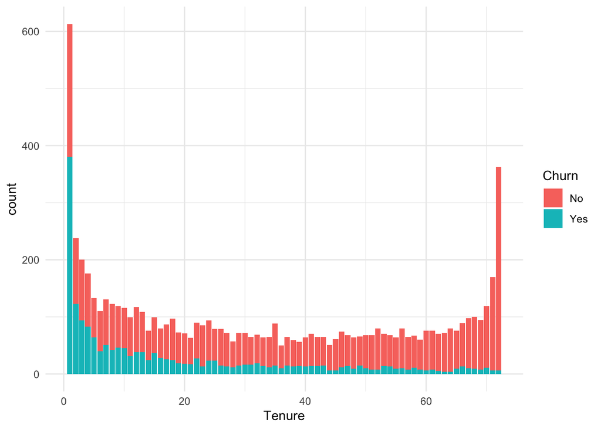

```r
ggplot(nvdatasetchurn, aes(x = tenure, fill = Churn)) +
  geom_bar() +
  labs(x = "Tenure") +
  theme_minimal()
```

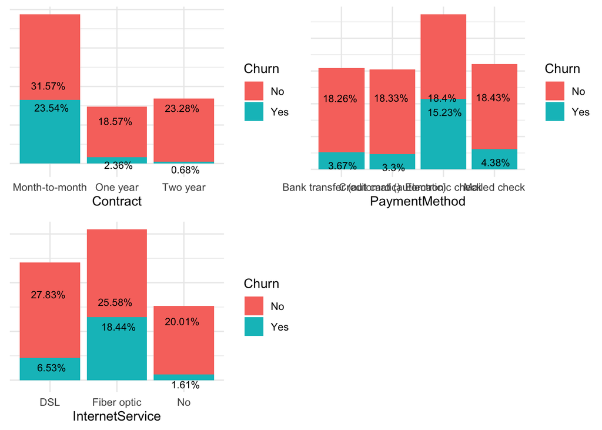

```r
plot_grid(ggplot(nvdatasetchurn, aes(x = Contract, fill = Churn)) +
            geom_bar() +
            geom_text(aes(y = ..count.. -200,
                          label = paste0(round(prop.table(..count..),4) * 100, '%')),
                      stat = 'count', position = position_dodge(.1), size = 3)+
            theme_minimal()+
             theme(axis.text.y = element_blank(),
              axis.ticks.y = element_blank(),
              axis.title.y = element_blank()),
          ggplot(nvdatasetchurn, aes(x = PaymentMethod, fill = Churn)) +
            geom_bar() +
            geom_text(aes(y = ..count.. -200,
                          label = paste0(round(prop.table(..count..),4) * 100, '%')),
                      stat = 'count', position = position_dodge(.1), size = 3)+
            theme_minimal()+
             theme(axis.text.y = element_blank(),
              axis.ticks.y = element_blank(),
              axis.title.y = element_blank()),
          ggplot(nvdatasetchurn, aes(x = InternetService, fill = Churn)) +
            geom_bar() +
            geom_text(aes(y = ..count.. -200,
                          label = paste0(round(prop.table(..count..),4) * 100, '%')),
                      stat = 'count', position = position_dodge(.1), size = 3)+
            theme_minimal()+
             theme(axis.text.y = element_blank(),
              axis.ticks.y = element_blank(),
              axis.title.y = element_blank()))
```

A maior parte dos clientes churn preferem o meio de pagamento Eletronic Check e possuem contratos mensais. Também preferem pelo serviço de internet Fiber optic.

Vamos dar uma olhada nas demais variáveis:

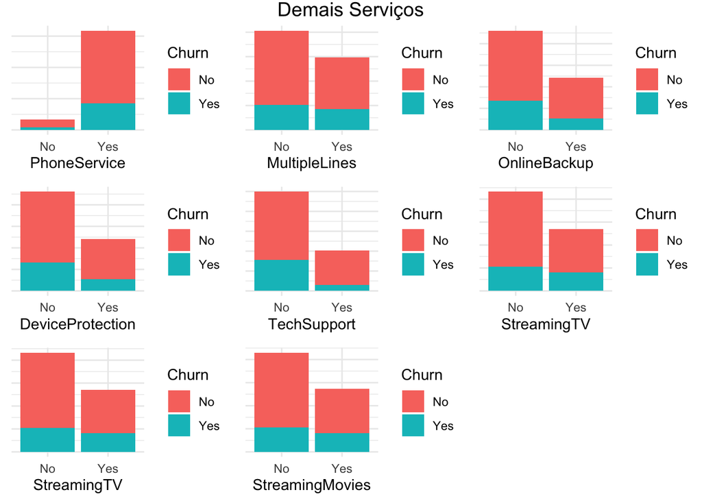

```r
plot_grid(ggplot(nvdatasetchurn, aes(x = PhoneService, fill = Churn)) +
            geom_bar()+
            theme_minimal()+
             theme(axis.text.y = element_blank(),
              axis.ticks.y = element_blank(),
              axis.title.y = element_blank()),
          ggplot(nvdatasetchurn, aes(x = MultipleLines, fill = Churn)) +
            geom_bar()+
            theme_minimal()+
             theme(axis.text.y = element_blank(),
              axis.ticks.y = element_blank(),
              axis.title.y = element_blank()),
          ggplot(nvdatasetchurn, aes(x = OnlineBackup, fill = Churn)) +
            geom_bar()+
            theme_minimal()+
             theme(axis.text.y = element_blank(),
              axis.ticks.y = element_blank(),
              axis.title.y = element_blank()),
          ggplot(nvdatasetchurn, aes(x = DeviceProtection, fill = Churn)) +
            geom_bar()+
            theme_minimal()+
             theme(axis.text.y = element_blank(),
              axis.ticks.y = element_blank(),
              axis.title.y = element_blank()),
          ggplot(nvdatasetchurn, aes(x = TechSupport, fill = Churn)) +
            geom_bar()+
            theme_minimal()+
             theme(axis.text.y = element_blank(),
              axis.ticks.y = element_blank(),
              axis.title.y = element_blank()),
          ggplot(nvdatasetchurn, aes(x = StreamingTV, fill = Churn)) +
            geom_bar()+
            theme_minimal()+
             theme(axis.text.y = element_blank(),
              axis.ticks.y = element_blank(),
              axis.title.y = element_blank()),
          ggplot(nvdatasetchurn, aes(x = StreamingTV, fill = Churn)) +
            geom_bar()+
            theme_minimal()+
             theme(axis.text.y = element_blank(),
              axis.ticks.y = element_blank(),
              axis.title.y = element_blank()),
          ggplot(nvdatasetchurn, aes(x = StreamingMovies, fill = Churn)) +
            geom_bar()+
            theme_minimal()+
             theme(axis.text.y = element_blank(),
              axis.ticks.y = element_blank(),
              axis.title.y = element_blank()))+
        labs(title = "Demais Serviços") +
        theme(plot.title = element_text(hjust = 0.5))
```

# **5. Modelo**

```r
library(caret)
set.seed(56)
split_train_test <- createDataPartition(nvdatasetchurn$Churn,p=0.7,list=FALSE)
dtrain<- nvdatasetchurn[split_train_test,]
dtest<-  nvdatasetchurn[-split_train_test,]
```

## 5.1 Decision Tree

A análise da árvore de decisão é um método de classificação que usa modelos de decisões em forma de árvore e seus possíveis resultados. Este método exploratório identificará as variáveis mais importantes relacionadas ao churn em um formato hierárquico.

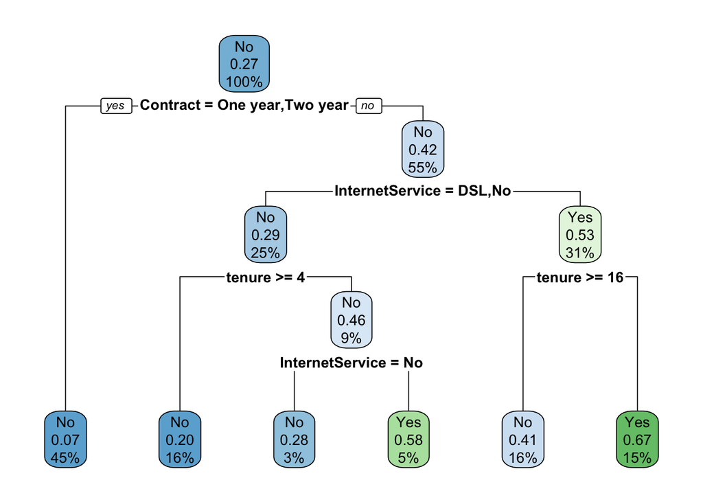

```r
library(rpart)
library(rpart.plot)

tr_fit <- rpart(Churn ~., data = dtrain, method="class")
rpart.plot(tr_fit)
```

A variável mais importante é *Contract*. Com o modelo podemos ver que os clientes mais engajados preferem contratos anuais, serviço de internet DSL e permanecem na empresa mais de 15 meses.

Para avaliar a precisão da nossa árvore de decisão vamos utilizar a matriz de confusão:

```r
tr_prob1 <- predict(tr_fit, dtest)
tr_pred1 <- ifelse(tr_prob1[,2] > 0.5,"Yes","No")
table(Predicted = tr_pred1, Actual = dtest$Churn)
```

```
##          Actual
## Predicted   No  Yes
##       No  1406  284
##       Yes  142  276
```

A partir dessa matriz de confusão, podemos ver que o modelo tem um bom desempenho na previsão de clientes não rotativos, mas não tem um desempenho tão bom na previsão de clientes rotativos.

E quanto a acuracidade do modelo?

```r
tr_prob2 <- predict(tr_fit, dtrain)
tr_pred2 <- ifelse(tr_prob2[,2] > 0.5,"Yes","No")
tr_tab1 <- table(Predicted = tr_pred2, Actual = dtrain$Churn)
tr_tab2 <- table(Predicted = tr_pred1, Actual = dtest$Churn)

# Treinamento
library(caret)
confusionMatrix(
  as.factor(tr_pred2),
  as.factor(dtrain$Churn),
  positive = "Yes"
)
```

```
## Confusion Matrix and Statistics
##
##           Reference
## Prediction   No  Yes
##        No  3272  674
##        Yes  343  635
##
##                Accuracy : 0.7935
##                  95% CI : (0.7819, 0.8047)
##     No Information Rate : 0.7342
##     P-Value [Acc > NIR] : < 2.2e-16
##
##                   Kappa : 0.4245
##
##  Mcnemar's Test P-Value : < 2.2e-16
##
##             Sensitivity : 0.4851
##             Specificity : 0.9051
##          Pos Pred Value : 0.6493
##          Neg Pred Value : 0.8292
##              Prevalence : 0.2658
##          Detection Rate : 0.1290
##    Detection Prevalence : 0.1986
##       Balanced Accuracy : 0.6951
##
##        'Positive' Class : Yes
##
```

```r
# Teste
confusionMatrix(
as.factor(tr_pred1),
  as.factor(dtest$Churn),
  positive = "Yes"
)
```

```
## Confusion Matrix and Statistics
##
##           Reference
## Prediction   No  Yes
##        No  1406  284
##        Yes  142  276
##
##                Accuracy : 0.7979
##                  95% CI : (0.7801, 0.8149)
##     No Information Rate : 0.7343
##     P-Value [Acc > NIR] : 6.398e-12
##
##                   Kappa : 0.4364
##
##  Mcnemar's Test P-Value : 8.405e-12
##
##             Sensitivity : 0.4929
##             Specificity : 0.9083
##          Pos Pred Value : 0.6603
##          Neg Pred Value : 0.8320
##              Prevalence : 0.2657
##          Detection Rate : 0.1309
##    Detection Prevalence : 0.1983
##       Balanced Accuracy : 0.7006
##
##        'Positive' Class : Yes
##
```

```r
tr_acc <- sum(diag(tr_tab2))/sum(tr_tab2)
tr_acc
```

```
## [1] 0.7979127
```

O modelo de árvore de decisão é bastante preciso, prevendo corretamente o status de rotatividade de clientes no subconjunto de teste 79% do tempo.

## 5.2 Random forest

A análise floresta aleatória é outro método de classificação de aprendizado de máquina freqüentemente usado na análise de rotatividade de clientes. O método opera construindo múltiplas árvores de decisão e construindo modelos com base em estatísticas resumidas dessas árvores de decisão.

Começaremos identificando o número de variáveis amostradas aleatoriamente. No pacote *randomForest*, isso é referido como o parâmetro ou argumento *‘mtry’*.

```r
#Definir parâmetros de controle para seleção aleatória de modelo de floresta
ctrl <- trainControl(method = "cv", number=5,
                     classProbs = TRUE, summaryFunction = twoClassSummary)

#Seleção exploratória de modelo de floresta aleatória
rf_fit1 <- train(Churn ~., data = dtrain,
                 method = "rf",
                 ntree = 75,
                 tuneLength = 5,
                 metric = "ROC",
                 trControl = ctrl)
rf_fit1
```

```
## Random Forest
##
## 4924 samples
##   19 predictor
##    2 classes: 'No', 'Yes'
##
## No pre-processing
## Resampling: Cross-Validated (5 fold)
## Summary of sample sizes: 3940, 3939, 3939, 3939, 3939
## Resampling results across tuning parameters:
##
##   mtry  ROC        Sens       Spec
##    2    0.8332208  0.9629322  0.3009798
##    8    0.8239186  0.8993084  0.4858764
##   15    0.8165053  0.8901798  0.4881665
##   22    0.8165443  0.8912863  0.4881665
##   29    0.8101833  0.8835408  0.4904478
##
## ROC was used to select the optimal model using the largest value.
## The final value used for the model was mtry = 2.
```

```r
saveRDS(rf_fit1, "Churn.RDS")

rf_fit1 <- readRDS("Churn.RDS")
```

O modelo descobriu que o valor ideal para *mtry* é 2. A partir deste modelo, podemos investigar a importância relativa das variáveis preditoras de rotatividade.

```r
library(randomForest)
```

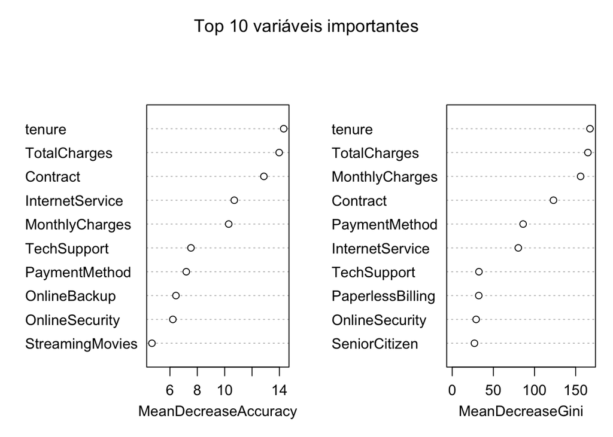

```r
rf_fit2 <- randomForest(Churn ~., data = dtrain,
                        ntree = 75, mtry = 2,
                        importance = TRUE, proximity = TRUE)

# Mostra a importância da variável da árvore aleatória
varImpPlot(rf_fit2, sort=T, n.var = 10,
           main = 'Top 10 variáveis importantes')
```

Semelhante à árvore de decisão, este modelo de floresta aleatório identificou *tenure* e *Contract* como preditores importantes para a rotatividade. Em contrapartida *Internet Service* não está entre os top 3 e é substituída por *TotalCharges*.

Vamos examinar o desempenho deste modelo de floresta aleatório. Começaremos com a matriz de confusão.

```r
rf_pred1 <- predict(rf_fit2, dtest)
table(Predicted = rf_pred1, Actual = dtest$Churn)
```

```
##          Actual
## Predicted   No  Yes
##       No  1433  289
##       Yes  115  271
```

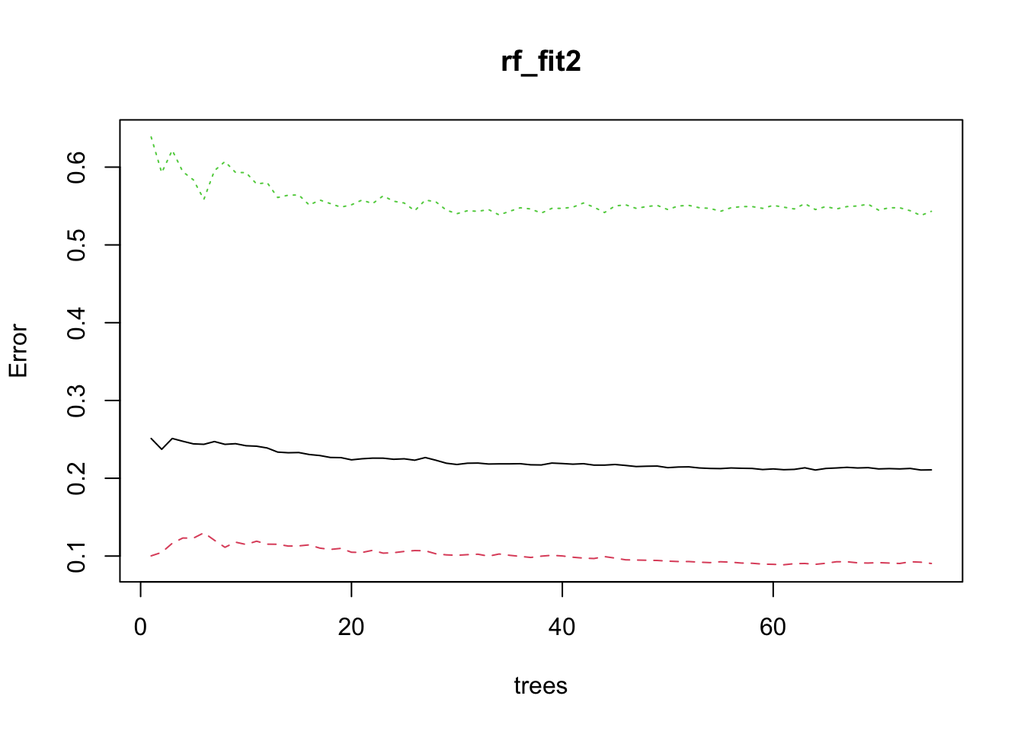

```r
plot(rf_fit2)
```

```r
rf_pred2 <- predict(rf_fit2, dtrain)
rf_tab1 <- table(Predicted = rf_pred2, Actual = dtrain$Churn)
rf_tab2 <- table(Predicted = rf_pred1, Actual = dtest$Churn)

# Treinamento
confusionMatrix(
  as.factor(rf_pred2),
  as.factor(dtrain$Churn),
  positive = "Yes"
)
```

```
## Confusion Matrix and Statistics
##
##           Reference
## Prediction   No  Yes
##        No  3466  445
##        Yes  149  864
##
##                Accuracy : 0.8794
##                  95% CI : (0.8699, 0.8883)
##     No Information Rate : 0.7342
##     P-Value [Acc > NIR] : < 2.2e-16
##
##                   Kappa : 0.6669
##
##  Mcnemar's Test P-Value : < 2.2e-16
##
##             Sensitivity : 0.6600
##             Specificity : 0.9588
##          Pos Pred Value : 0.8529
##          Neg Pred Value : 0.8862
##              Prevalence : 0.2658
##          Detection Rate : 0.1755
##    Detection Prevalence : 0.2057
##       Balanced Accuracy : 0.8094
##
##        'Positive' Class : Yes
##
```

```r
# Teste
confusionMatrix(
as.factor(rf_pred1),
  as.factor(dtest$Churn),
  positive = "Yes"
)
```

```
## Confusion Matrix and Statistics
##
##           Reference
## Prediction   No  Yes
##        No  1433  289
##        Yes  115  271
##
##                Accuracy : 0.8083
##                  95% CI : (0.7909, 0.825)
##     No Information Rate : 0.7343
##     P-Value [Acc > NIR] : 1.088e-15
##
##                   Kappa : 0.4547
##
##  Mcnemar's Test P-Value : < 2.2e-16
##
##             Sensitivity : 0.4839
##             Specificity : 0.9257
##          Pos Pred Value : 0.7021
##          Neg Pred Value : 0.8322
##              Prevalence : 0.2657
##          Detection Rate : 0.1286
##    Detection Prevalence : 0.1831
##       Balanced Accuracy : 0.7048
##
##        'Positive' Class : Yes
##
```

```r
rf_acc <- sum(diag(rf_tab2))/sum(rf_tab2)
rf_acc
```

```
## [1] 0.8083491
```

O modelo de floresta aleatória é um pouco mais preciso do que o modelo de árvore de decisão, sendo capaz de prever corretamente o status de rotatividade de um cliente no subconjunto de teste com 80% de precisão.

## 5.3 Logistic regression analysis

A regressão logística envolve a regressão de variáveis preditoras em um resultado binário usando uma função de ligação binomial. Vamos ajustar o modelo usando a função de modelagem linear geral básica em R, *‘glm’*.

```r
lr_fit <- glm(Churn ~., data = dtrain,
          family=binomial(link='logit'))
summary(lr_fit)
```

```
##
## Call:
## glm(formula = Churn ~ ., family = binomial(link = "logit"), data = dtrain)
##
## Deviance Residuals:
##     Min       1Q   Median       3Q      Max
## -1.8966  -0.6818  -0.2767   0.7457   3.2597
##
## Coefficients:
##                                        Estimate Std. Error z value Pr(>|z|)
## (Intercept)                           1.232e+00  9.637e-01   1.278 0.201258
## genderMale                           -1.242e-02  7.748e-02  -0.160 0.872611
## SeniorCitizenYes                      2.358e-01  1.001e-01   2.355 0.018532 *
## PartnerYes                           -7.698e-02  9.255e-02  -0.832 0.405513
## DependentsYes                        -1.896e-01  1.071e-01  -1.770 0.076691 .
## tenure                               -6.960e-02  7.728e-03  -9.006  < 2e-16 ***
## PhoneServiceYes                      -1.368e-01  7.678e-01  -0.178 0.858579
## MultipleLinesYes                      3.824e-01  2.088e-01   1.832 0.067023 .
## InternetServiceFiber optic            1.316e+00  9.422e-01   1.396 0.162633
## InternetServiceNo                    -1.700e+00  9.569e-01  -1.777 0.075603 .
## OnlineSecurityYes                    -2.218e-01  2.102e-01  -1.055 0.291466
## OnlineBackupYes                      -1.189e-01  2.074e-01  -0.573 0.566495
## DeviceProtectionYes                   3.831e-02  2.080e-01   0.184 0.853874
## TechSupportYes                       -3.033e-01  2.136e-01  -1.420 0.155750
## StreamingTVYes                        4.271e-01  3.854e-01   1.108 0.267716
## StreamingMoviesYes                    4.323e-01  3.863e-01   1.119 0.263076
## ContractOne year                     -6.228e-01  1.293e-01  -4.816 1.46e-06 ***
## ContractTwo year                     -1.389e+00  2.145e-01  -6.473 9.63e-11 ***
## PaperlessBillingYes                   3.205e-01  8.915e-02   3.595 0.000324 ***
## PaymentMethodCredit card (automatic) -2.102e-01  1.355e-01  -1.551 0.120894
## PaymentMethodElectronic check         2.365e-01  1.125e-01   2.103 0.035466 *
## PaymentMethodMailed check            -2.345e-01  1.384e-01  -1.694 0.090308 .
## MonthlyCharges                       -2.912e-02  3.752e-02  -0.776 0.437718
## TotalCharges                          4.636e-04  8.674e-05   5.344 9.08e-08 ***
## ---
## Signif. codes:  0 '***' 0.001 '**' 0.01 '*' 0.05 '.' 0.1 ' ' 1
##
## (Dispersion parameter for binomial family taken to be 1)
##
##     Null deviance: 5702.8  on 4923  degrees of freedom
## Residual deviance: 4074.2  on 4900  degrees of freedom
## AIC: 4122.2
##
## Number of Fisher Scoring iterations: 6
```

As variáveis *tenure*, *Contract* e *TotalCharges* têm os valores *p* mais baixos e podem ser identificados como os melhores preditores de rotatividade de clientes.

Vamos examinar a matriz de confusão com base em nosso modelo de regressão logística.

```r
lr_prob1 <- predict(lr_fit, dtest, type="response")
lr_pred1 <- ifelse(lr_prob1 > 0.5,"Yes","No")
table(Predicted = lr_pred1, Actual = dtest$Churn)
```

```
##          Actual
## Predicted   No  Yes
##       No  1403  247
##       Yes  145  313
```

A acuracidade pode ser obtida de forma semelhante aos modelos anteriores.

```r
lr_prob2 <- predict(lr_fit, dtrain, type="response")
lr_pred2 <- ifelse(lr_prob2 > 0.5,"Yes","No")
lr_tab1 <- table(Predicted = lr_pred2, Actual = dtrain$Churn)
lr_tab2 <- table(Predicted = lr_pred1, Actual = dtest$Churn)
```

```r
# Treinamento
confusionMatrix(
  as.factor(lr_pred2),
  as.factor(dtrain$Churn),
  positive = "Yes"
)
```

```
## Confusion Matrix and Statistics
##
##           Reference
## Prediction   No  Yes
##        No  3227  595
##        Yes  388  714
##
##                Accuracy : 0.8004
##                  95% CI : (0.7889, 0.8115)
##     No Information Rate : 0.7342
##     P-Value [Acc > NIR] : < 2.2e-16
##
##                   Kappa : 0.4614
##
##  Mcnemar's Test P-Value : 5.019e-11
##
##             Sensitivity : 0.5455
##             Specificity : 0.8927
##          Pos Pred Value : 0.6479
##          Neg Pred Value : 0.8443
##              Prevalence : 0.2658
##          Detection Rate : 0.1450
##    Detection Prevalence : 0.2238
##       Balanced Accuracy : 0.7191
##
##        'Positive' Class : Yes
##
```

```r
# Teste
confusionMatrix(
as.factor(lr_pred1),
  as.factor(dtest$Churn),
  positive = "Yes"
)
```

```
## Confusion Matrix and Statistics
##
##           Reference
## Prediction   No  Yes
##        No  1403  247
##        Yes  145  313
##
##                Accuracy : 0.814
##                  95% CI : (0.7968, 0.8304)
##     No Information Rate : 0.7343
##     P-Value [Acc > NIR] : < 2.2e-16
##
##                   Kappa : 0.494
##
##  Mcnemar's Test P-Value : 3.374e-07
##
##             Sensitivity : 0.5589
##             Specificity : 0.9063
##          Pos Pred Value : 0.6834
##          Neg Pred Value : 0.8503
##              Prevalence : 0.2657
##          Detection Rate : 0.1485
##    Detection Prevalence : 0.2173
##       Balanced Accuracy : 0.7326
##
##        'Positive' Class : Yes
##
```

```r
lr_acc <- sum(diag(lr_tab2))/sum(lr_tab2)
lr_acc
```

```
## [1] 0.8140417
```

A taxa de precisão de 81,4% do modelo de regressão logística supera ligeiramente os modelos de árvore de decisão e floresta aleatória.

# **6. Conclusão**

Depois de passar por várias etapas preparatórias, incluindo carregamento de dados/biblioteca e pré-processamento, realizamos três métodos de classificação estatística comuns na análise de churn. Identificamos várias variáveis preditoras de rotatividade importantes desses modelos e comparamos esses modelos em medidas de precisão.

Em suma: